# Klasse-C slides

Klasse C versterkers

Hoogfrequent versterkers  
met 1 vermogentransistor

Jan Genoe

September 2026

###### Basisschema van de Klasse C versterker

[figure not shown]

###### Detail: de trilkring

[figure not shown]

###### Verklaring van de werking (1)

- Zonder sturing actief element
  - De inductantie (L) wisselt met de condensator (C) energie uit: trilling op de eigenfrequentie
  - Amplitude van de oscillatie daalt (de trilling dempt uit) door energieoverdracht naar de belasting R<sub>L</sub>

###### Berekening trilkring

Op basis van de eerste wet van Kirchhoff

###### Berekening trilkring

$$ I_C+ I_R + I_L =0 $$

$$ Q_C= C V $$

$$ I_R R_L = V $$

$$ L \frac{d I_L}{dt} = V $$

###### Berekening trilkring (2)

Van lading op C naar stroom naar de C

$$ I_C+ I_R + I_L =0 $$

$$ I_C= C \frac{d V}{dt} $$

$$ I_R R_L = V $$

$$ L \frac{d I_L}{dt} = V $$

###### Berekening trilkring (3)

Afgeleide van de stromen:

###### Berekening trilkring (3)

$$ \frac{d I_C}{dt}+ \frac{d I_R}{dt} + \frac{d I_L}{dt} =0 $$

$$ \frac{d I_C}{dt}= C \frac{d^2 V}{dt^2} $$

$$ \frac{d I_R}{dt} =\frac{1}{R_L} \frac{d V}{dt} $$

$$ \frac{d I_L}{dt} =\frac{1}{L} V $$

###### Berekening trilkring

Invullen geeft dan:

$$C \frac{d^2 V}{dt^2} + \frac{1}{R_L} \frac{d V}{dt} + \frac{1}{L} V = 0$$

###### Berekening trilkring

De spanning V evolueert als functie van de tijd als:

###### Berekening trilkring

$$V(t)= V_o \cos(\omega t +\phi) \exp(-\beta t)$$

In deze vergelijking hebben we 2 parameters die bepaald worden door de componenten in het circuit, namelijk $\beta$ en $\omega$. Deze zijn:

$$ \beta=\frac{1}{2 R_L C} $$

$$ \omega =\sqrt{\frac{1}{L C}- \beta^2}$$

###### Gedempte trilkring

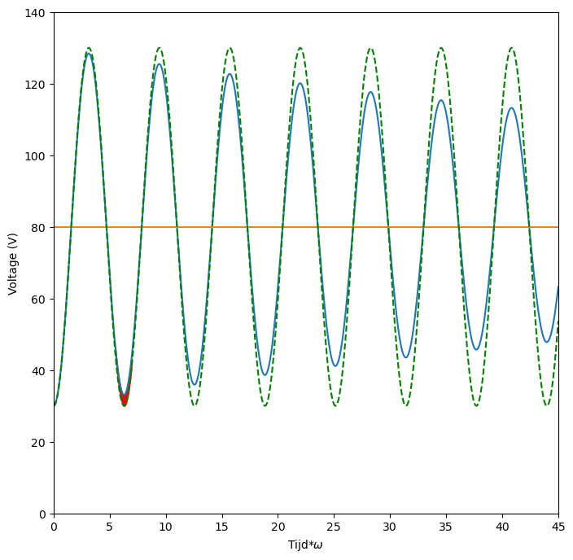

###### Keuze van de parameters

We bepalen eerst C<sub>1</sub>

En vervolgens L<sub>1</sub>

###### Keuze van de parameters

$$ \beta=\frac{1}{2 R_L C_1} $$

$$ \omega =\sqrt{\frac{1}{L_1 C_1}- \beta^2}$$

###### Benadering resonantiefrequentie

###### Benadering resonantiefrequentie

$$ \omega =\sqrt{\frac{1}{L_1 C_1}}$$

$$ P_{AC} =\frac{V_{AC}^2}{2 R_L}$$

###### Basisschema van de Klasse C versterker

[figure not shown]

###### Instelling basisstroom: door keuze geleidingshoek en piekstroom

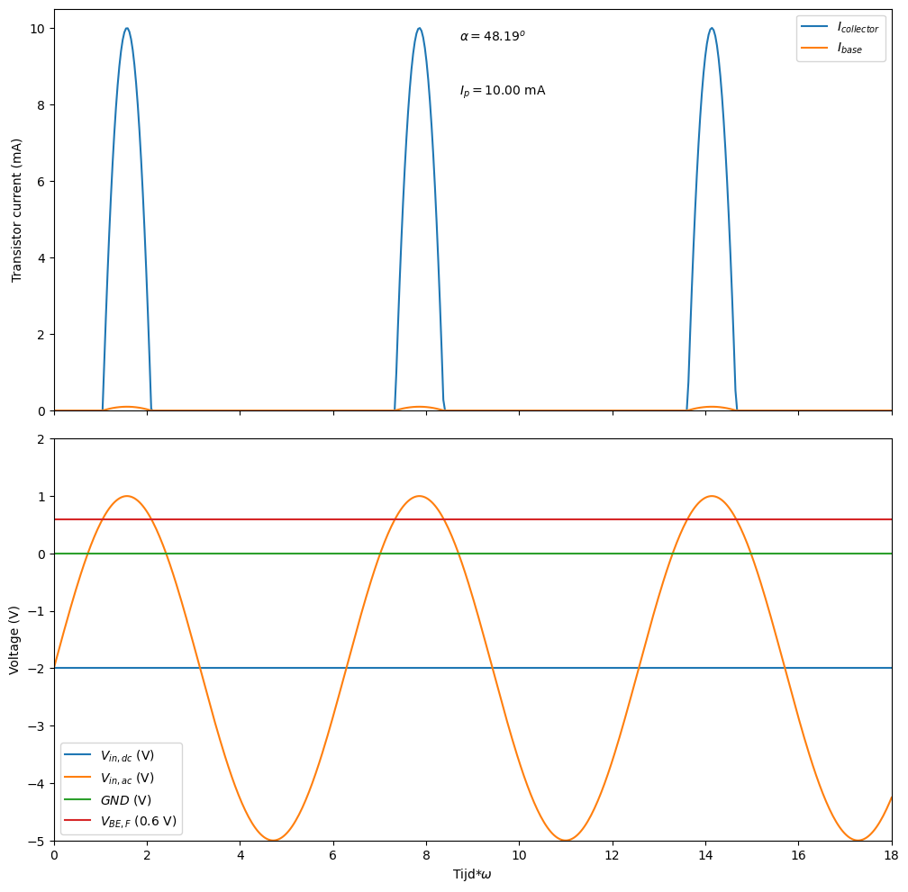

###### SPICE file Klasse C circuit

```
* Class C amp 1
Q_Q1         2 1 0 Q2
L_L1         2 3  1uH
C_C1         2 3  10nF
R_RL         2 3  60
V_Vdd        3 0 11V
R_Rin        4 1 100
V_Vin        4 0 sin(-1.5 2.7 1591500) DC=-1.5
.model Q2  NPN(Is=14.34f BF=200)
```

###### Basisschema met knopen genummerd

[figure not shown]

###### Spice simulatie: spanningen

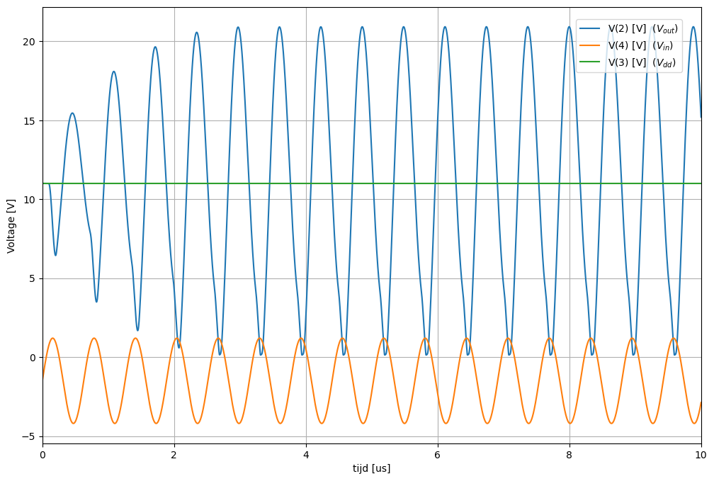

###### Spice simulatie: stromen

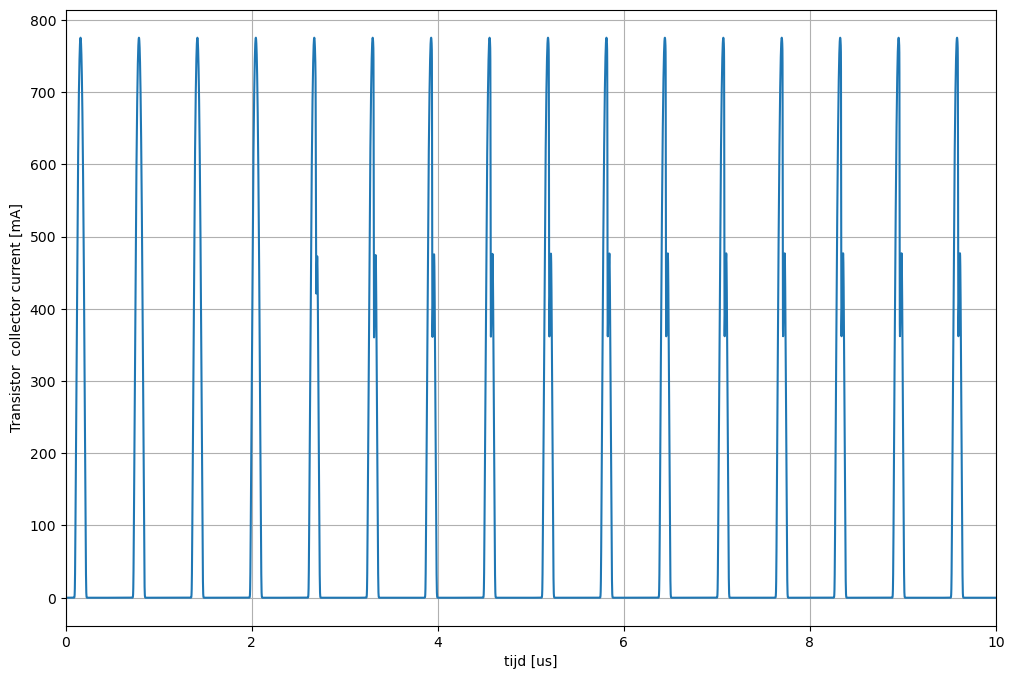

###### Spice simulatie van de spanningen en stromen

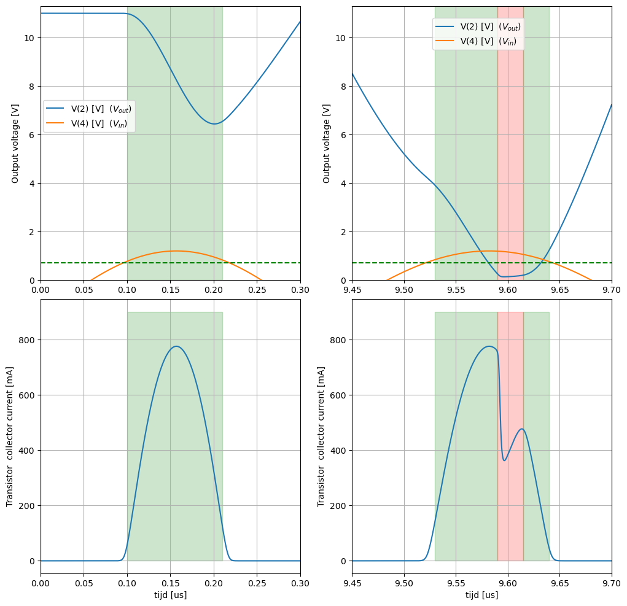

###### Lissajous figuur: knoop 2 en knoop 4

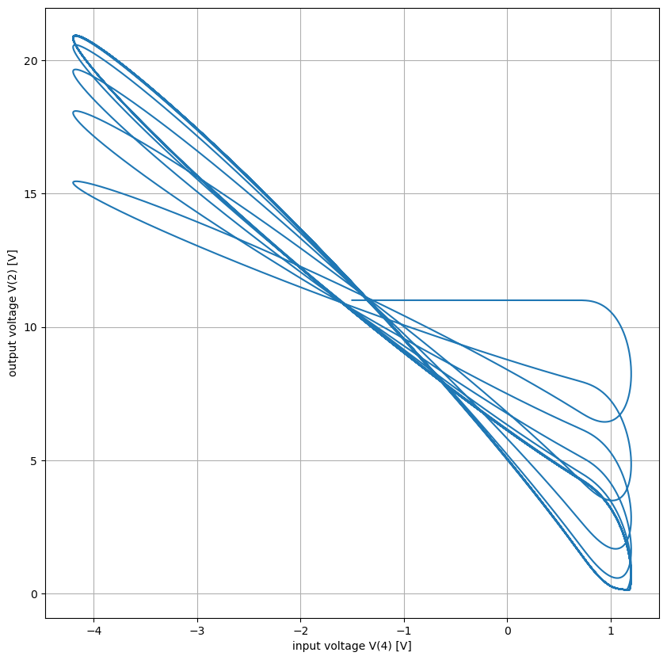

###### Ontwerpparameters en bekomen oscillatie

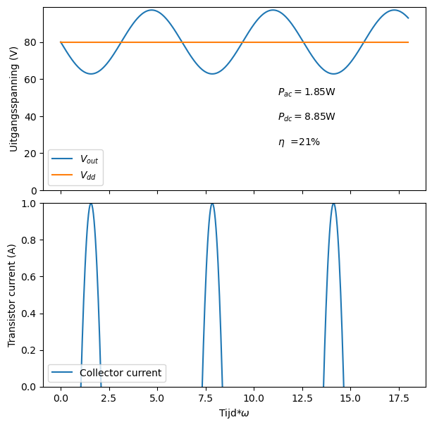

###### Uitgangspower en DC power

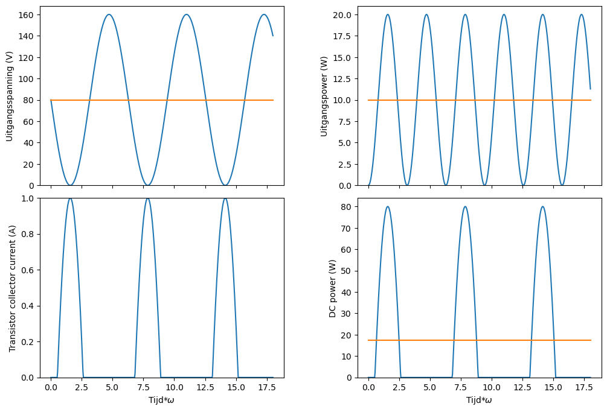

###### Transistor power

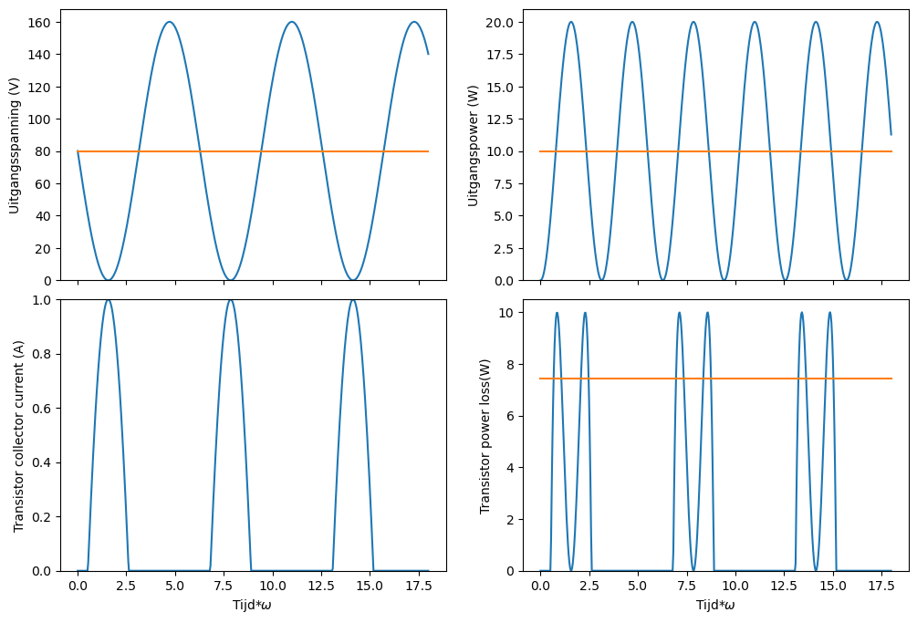

###### Drive transistor:verloop stromen en spanningen

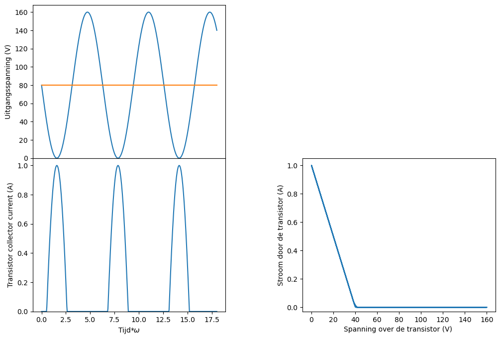

###### Bekomen oscillatiespanning als functie van de geleidingshoek ($\alpha$)

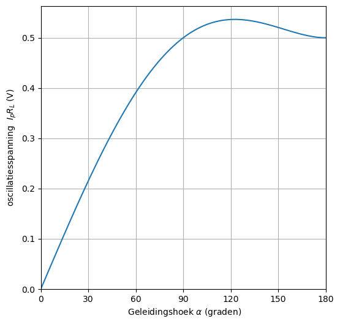

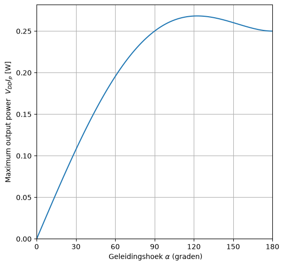

###### Nodige piekstroom om voedingsspanning als zwaai te bekomen

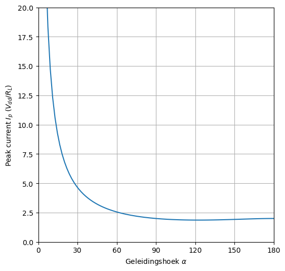

###### Bekomen rendement bij maximale uitsturing

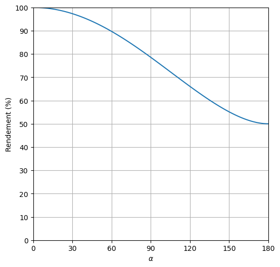

- Bij geleidingshoek $\alpha$ = 0 hebben we een rendement van 100%. De transistor is hierbij echter over heel de periode nooit in geleiding en er kan dus ook geen energie aan het circuit worden toegevoegd. Er wordt geen vermogen aan de uitgang bekomen.
- Bij geleidingshoek $\alpha$ =$\pi /2$ hebben we een rendement van 78%. De transistor is hierbij de helft van de periode in geleiding, zoals bij een klasse B versterker. Hetzelfde maximale rendement als bij een klasse B versterker wordt dan ook bekomen.
- Bij geleidingshoek $\alpha$ =$\pi$ hebben we een rendement van 50%. De transistor is hierbij de hele periode in geleiding, zoals bij een klasse A versterker. Hetzelfde maximale rendement als bij een klasse A versterker wordt dan ook bekomen.

##### (Links) impedantie van de LRC-kring als functie van de frequentie (Rechts) het uitdempen van deze kring als functie van de tijd

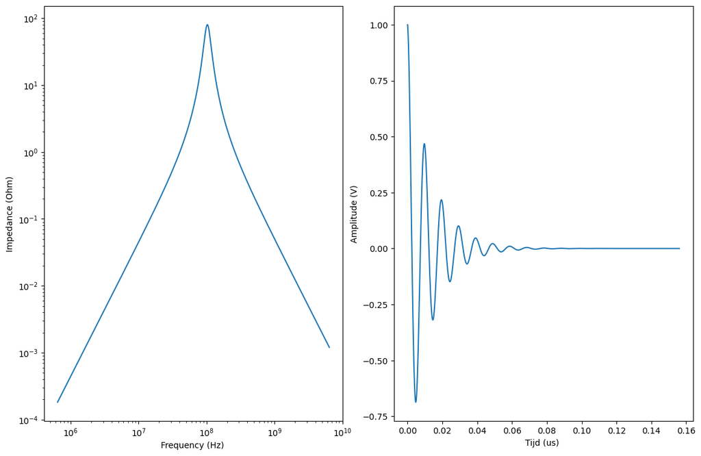

###### SPICE file Klasse C circuit

```
* Class C amp 1
Q_Q1         2 1 0 Q2
L_L1         2 3  1uH
C_C1         2 3  10n
R_RL         2 3  60
V_Vdd        3 0 11V
R_Rin        4 1 100
V_Vin        4 5  AC 0.5V 0 DC 0
V_VinDC      5 0 0.7V
.model Q2  NPN(Is=14.34f BF=200)
```

###### Knoop 2 (spice simulatie)

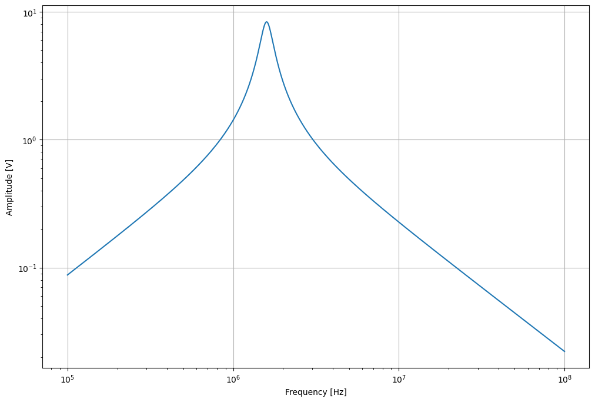

###### Contributies harmonischen aanstuursignaal

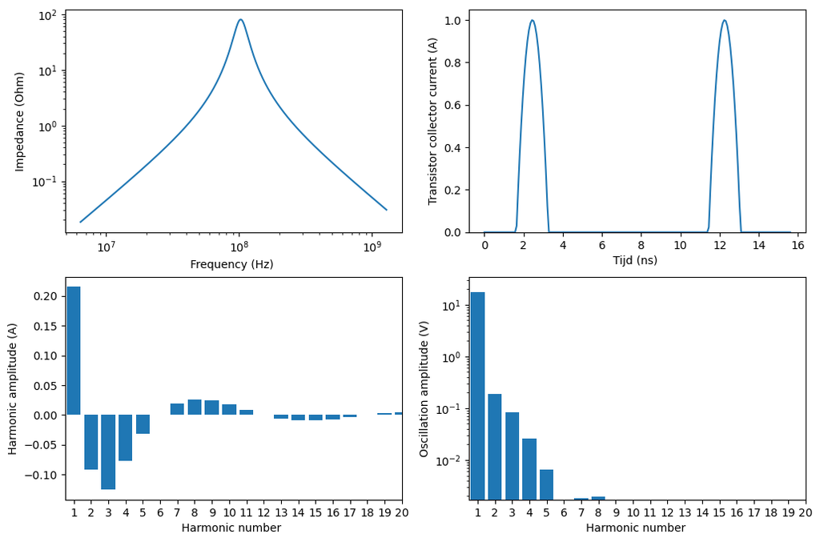

###### Aansturing met een blokgolf

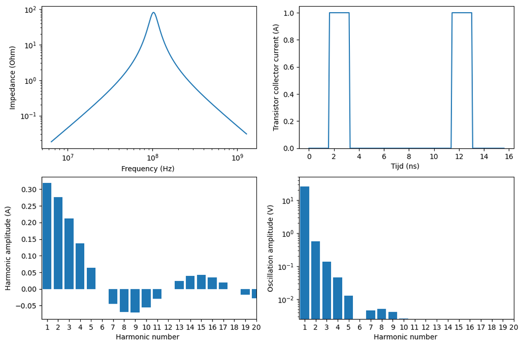

###### Klasse C versterker met een transformator in de resonante kring

[figure not shown]

###### Klasse C versterker met een LC kring aan de ingang van de transistor

[figure not shown]

###### Klasse C versterker waarbij de uitgangspanning oscilleert rond de grond

[figure not shown]

###### SPICE file Klasse C circuit (uitgang grond)

```
* klasseC   versie2
Q_Q1         2 1 0  Q2
L_L1         0 3    1uH
C_C1         0 3    10n
R_R1         0 3    100
V_V3         4 0    11V
V_V5         1 0    sin(-2 3.09 1591500) DC=-2
C_C2         2 3    100n
L_L2         2 4    20uH
.model Q2  NPN(Is=14.34f BF=255.9 Rb=100 )
```

###### Resultaat van de spice simulatie van het bovenstaande circuit

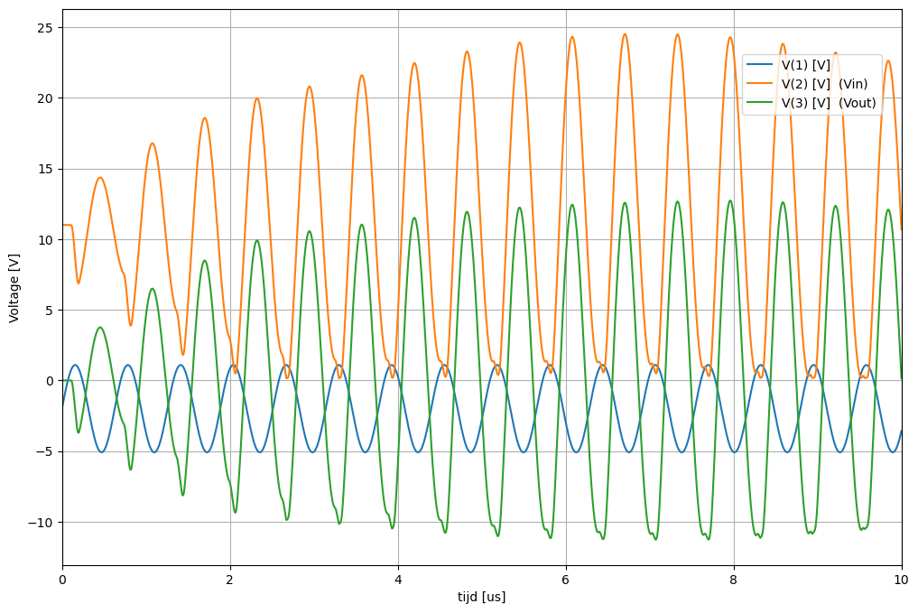

###### Meerdere versterkingstrappen

## Meerdere versterkingstrappen

###### Stap1: verschillende voedingsspanning

[figure not shown]

###### Stap 2: andere versie Vdd2

[figure not shown]

###### Stap 3: diode als belasting

[figure not shown]

###### Stap 4: diode -> transistor

[figure not shown]

###### Stap 5: belast met tweede resonante kring (zelfde frequentie)

[figure not shown]

###### Implementatie met 3 klasse C trappen

[figure not shown]

###### IC implementatie

[figure not shown]

###### Plaatmodulatie voor een AM zender

[figure not shown]

I would rather have questions that can't be answered  
than answers that can't be questioned.

Richard Feynman